# 6 & 7 Obtaining the Posterior: Grid Approximation & MCMC

Author

Johnny van Doorn

Published

June 10, 2026

By the end of this lecture, you will be able to:

- Explain why conjugate models are limited and when you must go beyond them
- Implement **grid approximation** to obtain posterior samples for non-conjugate models
- Explain the intuition behind **Markov Chain Monte Carlo (MCMC)** and the Metropolis algorithm
- Read the key MCMC convergence diagnostics (trace plots, $\hat R$, effective sample size)
- Use posterior samples — regardless of how they were obtained — to compute summaries

**Recommended Reading:** *Bayes Rules!* Chapters 6 (approximating the posterior) and 7 (MCMC under the hood). Suggested exercises: Ch. 6 — 2, 4, 6, 8, 10; Ch. 7 — 2, 4, 6.

# Review: Four Ingredients of a Bayesian Analysis

Every Bayesian model is built on the same four components, regardless of model complexity.

**The four ingredients**

1. **Prior model** — beliefs about parameter $\theta$ before seeing data: $f(\theta)$
2. **Data model (likelihood)** — how data arise given the parameter: $f(y \mid \theta)$
3. **Likelihood function** — the same expression viewed as a function of $\theta$ with $y$ fixed: $L(\theta \mid y) \propto f(y \mid \theta)$
4. **Posterior model** — updated beliefs after seeing data: $f(\theta \mid y) \propto f(\theta) \cdot L(\theta \mid y)$

The three conjugate families from last lecture:

| Likelihood | Prior | Posterior |
| --- | --- | --- |
| Binomial$(n, \theta)$ | Beta$(\alpha, \beta)$ | Beta$(\alpha+y,\;\beta+n-y)$ |
| Poisson$(\lambda)$ | Gamma$(s, r)$ | Gamma$(s+\sum y_i,\; r+n)$ |
| Normal$(\mu, \sigma^2)$, $\sigma$ known | Normal$(\mu_0, \tau^2)$ | Normal$(\mu_\text{post}, \sigma^2_\text{post})$ |

**Today** we ask: what happens when the model is *not* conjugate, or when the posterior simply has no closed form? We turn to numerical approximations — grid approximation and MCMC.

# Running Example: Dutch Railways

We will use one running example throughout this lecture, starting with a conjugate set-up and then breaking it.

**Scenario**

You are a data analyst for the Dutch Railway Service (NS). Your task: model the **monthly rate of signal failures** on a 10 km stretch of track.

- Parameter: $\lambda =$ mean failures per month
- Likelihood: $Y_i \mid \lambda \overset{\text{iid}}{\sim} \text{Poisson}(\lambda)$
- Prior: Gamma(2, 0.5) — failures are relatively rare, modest prior certainty (mean = 4)

```r
library(bayesrules)

# Observed 4 months: y = (2, 0, 3, 1)
y <- c(2, 0, 3, 1)

# Posterior: Gamma(s + sum(y), r + n) = Gamma(8, 4.5)
s_post <- 2 + sum(y)
r_post <- 0.5 + length(y)
cat("Posterior: Gamma(", s_post, ",", r_post, ")\n")
```

```
Posterior: Gamma( 8 , 4.5 )
```

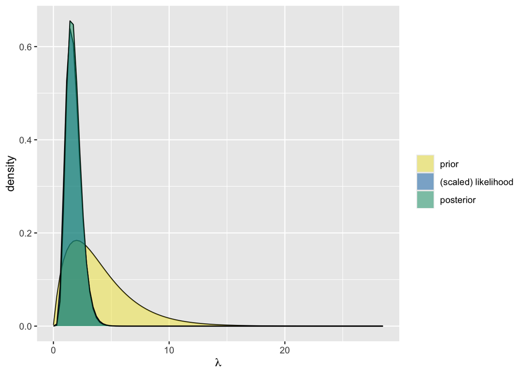

```r
plot_gamma_poisson(shape = 2, rate = 0.5, sum_y = sum(y), n = length(y))
```

```r
summarize_gamma_poisson(shape = 2, rate = 0.5, sum_y = sum(y), n = length(y))
```

| model | shape | rate | mean | mode | var | sd |
| --- | --- | --- | --- | --- | --- | --- |
| prior | 2 | 0.5 | 4.000000 | 2.000000 | 8.0000000 | 2.8284271 |
| posterior | 8 | 4.5 | 1.777778 | 1.555556 | 0.3950617 | 0.6285394 |

So far so familiar — the Gamma–Poisson is conjugate, and the posterior is a clean Gamma(8, 4.5). But what if the engineer’s prior beliefs *aren’t* Gamma-shaped? Maybe she’s confident that $\lambda$ lies in $[1, 5]$ and is unwilling to commit to a particular shape within that range. Or maybe she has two competing hypotheses about the maintenance regime that suggest a bimodal prior. The conjugacy trick breaks — but the mathematics

$$f(\lambda \mid y) \propto f(\lambda) \cdot L(y \mid \lambda)$$

still holds. We just can’t read off the answer in closed form. That’s the puzzle the rest of this lecture solves.

# Beyond Conjugacy: Grid Approximation & MCMC

Conjugate models require prior and likelihood to match. Real research often involves:

- Multiple unknown parameters
- Non-standard prior shapes (truncated, mixture)
- Complex hierarchical models

The good news: $f(\theta \mid y) \propto f(\theta) \cdot L(y \mid \theta)$ always holds. We just need numerical methods to compute usable summaries.

## Grid Approximation

1. Define a grid: $\theta_1, \ldots, \theta_K$
2. Evaluate unnormalised posterior at each point: $u_i = f(\theta_i) \cdot L(y \mid \theta_i)$
3. Normalise: $\hat{f}(\theta_i \mid y) = u_i / \sum_j u_j$
4. Sample from the grid with probabilities proportional to $\hat{f}$

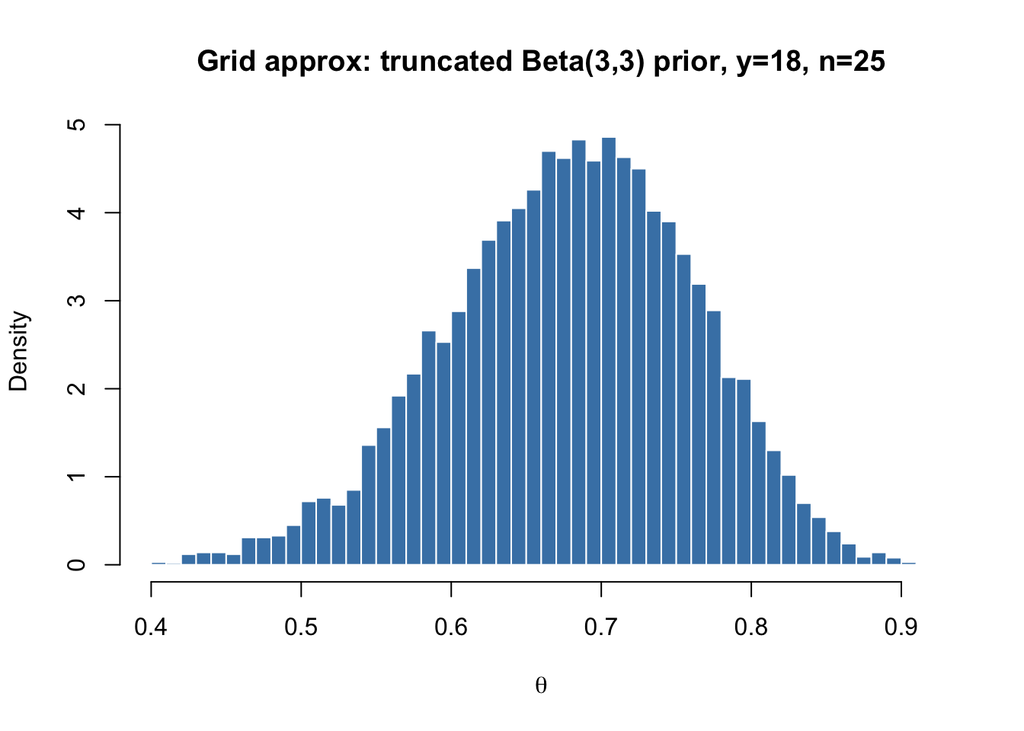

```r
# Non-conjugate example: Beta(3,3) prior truncated to [0.4, 1]
theta_grid <- seq(0, 1, length.out = 2000)

prior      <- dbeta(theta_grid, 3, 3) * (theta_grid >= 0.4)
likelihood <- dbinom(18, size = 25, prob = theta_grid)

unnorm         <- prior * likelihood
posterior_grid <- unnorm / sum(unnorm)

theta_samples <- sample(theta_grid, size = 1e4,
                        replace = TRUE, prob = posterior_grid)

hist(theta_samples, breaks = 50, probability = TRUE,
     main = "Grid approx: truncated Beta(3,3) prior, y=18, n=25",
     xlab = expression(theta), col = "steelblue", border = "white")
```

```r
cat("Posterior mean:", round(mean(theta_samples), 3), "\n")
```

```
Posterior mean: 0.679
```

```r
cat("95% ETI: [", round(quantile(theta_samples, 0.025), 3),
    ",", round(quantile(theta_samples, 0.975), 3), "]\n")
```

```
95% ETI: [ 0.507 , 0.827 ]
```

**Limitation:** Grid points grow as $K^p$ with the number of parameters $p$. With 10 parameters and 100 grid points each, you need $100^{10} = 10^{20}$ evaluations — infeasible.

## MCMC — The Intuition

**Markov Chain Monte Carlo** draws samples from the posterior *without* computing the normalising constant.

**The island-hopping metaphor** (Metropolis algorithm)

A politician visits islands whose populations represent posterior density:

1. Propose a neighbouring island at random
2. If it’s bigger → always move
3. If it’s smaller → move with probability = (proposed / current population)
4. Otherwise → stay put

Long-run time spent on each island $\propto$ population — without ever needing the total.

In practice, use `brms` (which calls Stan). Key diagnostics to check:

| Term | Meaning |
| --- | --- |
| **Trace plot** | $\theta^{(t)}$ vs. $t$ — should look like a “hairy caterpillar” |
| **Burn-in** | Early samples discarded while chain finds the posterior |
| **$\hat{R}$** | Convergence — should be near 1.00 |
| **Effective N** | Consecutive samples are correlated; effective N < actual N |

Once you have MCMC draws, all posterior summaries work exactly the same as with conjugate samples:

```r
# theta_mcmc: any posterior sample (grid, MCMC, conjugate — identical workflow)
theta_mcmc <- theta_samples

mean(theta_mcmc)                        # posterior mean
```

```
[1] 0.6790098
```

```r
median(theta_mcmc)                      # posterior median
```

```
[1] 0.6828414
```

```r
mean(theta_mcmc > 0.6)                  # P(theta > 0.6 | y)
```

```
[1] 0.8282
```

```r
quantile(theta_mcmc, c(0.025, 0.975))   # 95% ETI
```

```
     2.5%     97.5%
0.5072411 0.8269135
```

# In-Class Exercises

## Exercise 1: Grid Approximation with a Truncated Prior

> A researcher believes the placebo effect rate is between 30% and 90%, and is otherwise uncertain. Prior: Beta(2,2) truncated to $[0.30, 0.90]$. Observed: 18 of 25 patients improve.

**Exercise**

1. Implement the grid approximation.
2. Compute the posterior mean and 95% ETI.
3. Compare to an untruncated Beta(2,2) — how much does the truncation matter here?

**Solution**

```r
theta_grid <- seq(0, 1, length.out = 5000)
y_obs <- 18; n_obs <- 25

# Truncated prior
prior_trunc <- dbeta(theta_grid, 2, 2) *
               (theta_grid >= 0.3 & theta_grid <= 0.9)
lik         <- dbinom(y_obs, n_obs, prob = theta_grid)
post_trunc  <- (prior_trunc * lik) / sum(prior_trunc * lik)
samp_trunc  <- sample(theta_grid, 1e4, replace = TRUE, prob = post_trunc)

# Untruncated
prior_full <- dbeta(theta_grid, 2, 2)
post_full  <- (prior_full * lik) / sum(prior_full * lik)
samp_full  <- sample(theta_grid, 1e4, replace = TRUE, prob = post_full)

cat("Truncated: mean =", round(mean(samp_trunc), 3),
    " 95% ETI = [", round(quantile(samp_trunc, 0.025), 3),
    ",",             round(quantile(samp_trunc, 0.975), 3), "]\n")
```

```
Truncated: mean = 0.689  95% ETI = [ 0.517 , 0.838 ]
```

```r
cat("Full:      mean =", round(mean(samp_full),  3),
    " 95% ETI = [", round(quantile(samp_full,  0.025), 3),
    ",",             round(quantile(samp_full,  0.975), 3), "]\n")
```

```
Full:      mean = 0.69  95% ETI = [ 0.513 , 0.84 ]
```

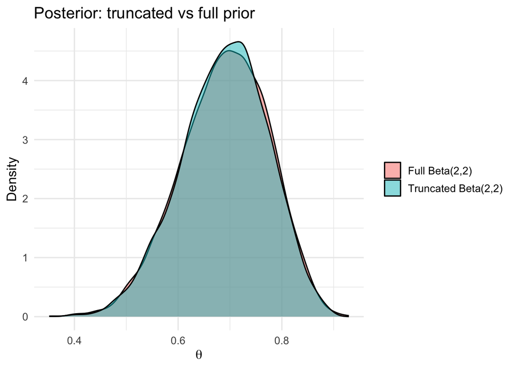

```r
df_plot <- data.frame(
  theta = c(samp_trunc, samp_full),
  Prior = rep(c("Truncated Beta(2,2)", "Full Beta(2,2)"), each = 1e4)
)
ggplot(df_plot, aes(x = theta, fill = Prior)) +
  geom_density(alpha = 0.5) +
  labs(title = "Posterior: truncated vs full prior",
       x = expression(theta), y = "Density") +
  theme_minimal(base_size = 13) +
  theme(legend.title = element_blank())
```

## Exercise 2: Metropolis by hand (Dutch Railways)

> Back to NS signal failures with prior Gamma(2, 0.5) and data $y = (2, 0, 3, 1)$. Pretend you’ve forgotten that the conjugate posterior is Gamma(8, 4.5). Build a tiny Metropolis sampler instead and compare.

**Exercise**

1. Implement a Metropolis sampler for $\lambda > 0$ with a Normal proposal centred at the current value (e.g. SD = 0.5). Use the **unnormalised** posterior $f(\lambda) \cdot L(y \mid \lambda)$ in the acceptance ratio.
2. Run 5,000 iterations, discard the first 1,000 as burn-in.
3. Compare your sampled mean and 95% ETI to the analytic posterior Gamma(8, 4.5).
4. Produce a trace plot. Does the chain look like a “hairy caterpillar”?

**Solution**

```r
set.seed(2026)

y <- c(2, 0, 3, 1)

log_post <- function(lambda) {
  if (lambda <= 0) return(-Inf)
  dgamma(lambda, shape = 2, rate = 0.5, log = TRUE) +
    sum(dpois(y, lambda, log = TRUE))
}

n_iter   <- 5000
lambda   <- numeric(n_iter)
lambda[1] <- 1            # starting value
accepts  <- 0

for (t in 2:n_iter) {
  proposal <- rnorm(1, mean = lambda[t - 1], sd = 0.5)
  log_a <- log_post(proposal) - log_post(lambda[t - 1])
  if (log(runif(1)) < log_a) {
    lambda[t] <- proposal
    accepts   <- accepts + 1
  } else {
    lambda[t] <- lambda[t - 1]
  }
}

cat("Acceptance rate:", round(accepts / (n_iter - 1), 3), "\n")
```

```
Acceptance rate: 0.742
```

```r
post <- lambda[1001:n_iter]                       # burn-in
cat("MCMC mean :", round(mean(post), 3), "\n")
```

```
MCMC mean : 1.77
```

```r
cat("Analytic  :", round(8 / 4.5, 3), "\n")
```

```
Analytic  : 1.778
```

```r
cat("MCMC 95% ETI:", round(quantile(post, c(.025, .975)), 3), "\n")
```

```
MCMC 95% ETI: 0.756 3.145
```

```r
cat("Analytic   :", round(qgamma(c(.025, .975), 8, 4.5), 3), "\n")
```

```
Analytic   : 0.768 3.205
```

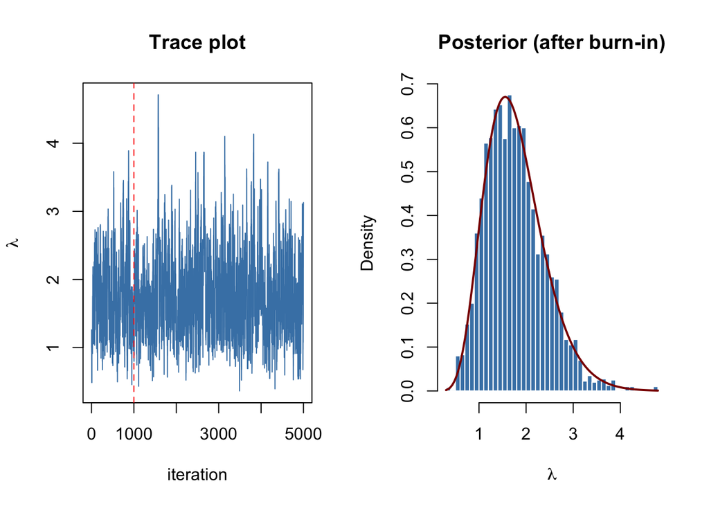

```r
par(mfrow = c(1, 2))
plot(lambda, type = "l", col = "steelblue",
     xlab = "iteration", ylab = expression(lambda),
     main = "Trace plot")
abline(v = 1000, col = "red", lty = 2)
hist(post, breaks = 40, probability = TRUE, col = "steelblue",
     border = "white", main = "Posterior (after burn-in)",
     xlab = expression(lambda))
curve(dgamma(x, 8, 4.5), add = TRUE, col = "darkred", lwd = 2)
```

```r
par(mfrow = c(1, 1))
```

The MCMC mean and ETI should sit very close to the analytic Gamma(8, 4.5) values — same posterior, two different routes.

**Next lectures (June 15):** Two parallel lectures use this same posterior machinery for *inference*. **Lecture 6a** focuses on posterior prediction, prior + posterior predictive checks, and hypothesis specification (Ch. 8 + Etz et al. 2018). **Lecture 6b** revisits the Dutch Railways posterior to build point estimates, credible intervals, and Bayes factors (Ch. 8.1–8.2 + addendum on testing point hypotheses).